# assessmentdata_testing

Abigail Tyrell

24 Nov 2020

## Test of assesssmentdata data, species: Smooth skate

This is a test report of `assessmentdata` data.

This report is pulling information on all Northeast Smooth skate stocks.

B/Bmsy and F/Fmsy were plotted against time. If there were 30 or more years of data, a geom_gls regression line was fit (yellow = significant increase; purple = significant decrease; no line = no significant trend). If there were fewer than 30 years of data, no regression was fit.

B/Bmsy was classified as “DANGER” if it was below 1 and “GOOD” if it was above 1.

F/Fmsy was classified as “DANGER” if it was above 1 and “GOOD” if it was below 1.

Recruitment was plotted against time for all years of data and for only the past 20 years of data. In both cases, a geom_gls regression line was fit (yellow = significant increase; purple = significant decrease; no line = no significant trend).

### B/Bmsy

The most recent status of B/Bmsy is: DANGER

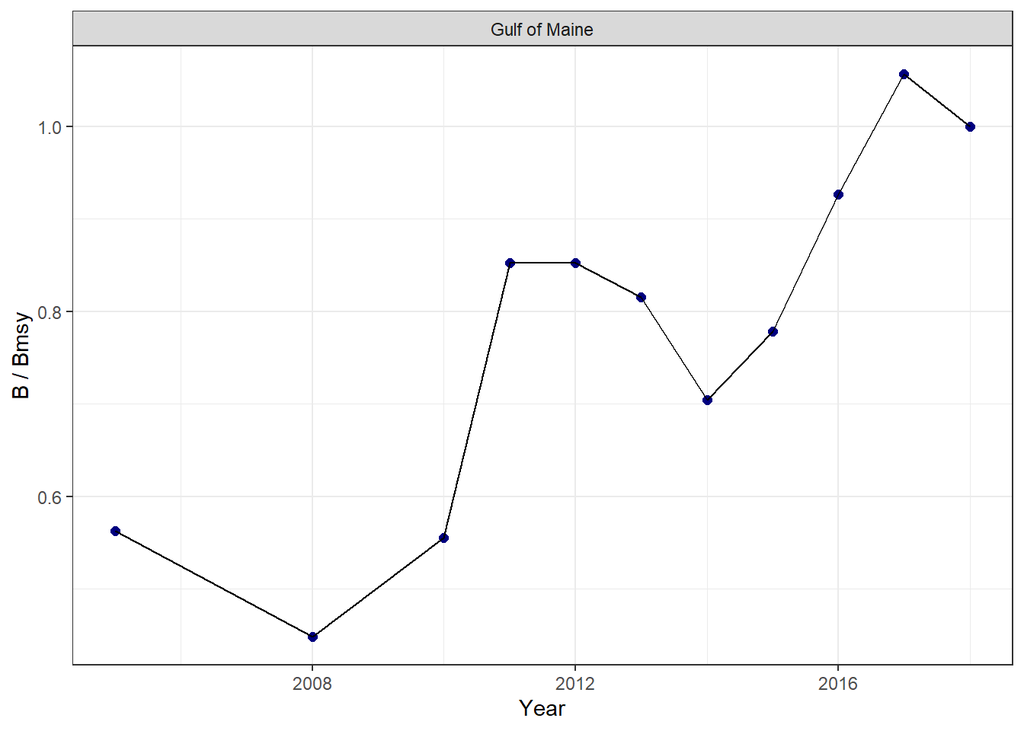

### F/Fmsy

The most recent status of F/Fmsy is: UNKNOWN

```
## [1] "NO DATA"
```

### Recruitment

#### Past 20 years

```
## [1] "NO DATA"
```

#### All years

```
## [1] "NO DATA"
```